```python
import numpy as np
import pandas as pd
import seaborn as sns
import matplotlib.pyplot as plt
%matplotlib inline
```

# Observation

## Importing all the Libraries

```python
dataset = pd.read_csv("D:/AI-Project/vehicle-1.csv")
```

# Observation

## Read the file vehicle-1.csv

```python
dataset.head()
```

|  | compactness | circularity | distance_circularity | radius_ratio | pr_axis_aspect_ratio | max_length_aspect_ratio | scatter_ratio | elongatedness | pr_axis_rectangularity | max_length_rectangularity | scaled_variance | scaled_variance_1 | scaled_radius_of_gyration | scaled_radius_of_gyration_1 | skewness_about | skewness_about_1 | skewness_about_2 | hollows_ratio | classtype |
| --- | --- | --- | --- | --- | --- | --- | --- | --- | --- | --- | --- | --- | --- | --- | --- | --- | --- | --- | --- |
| 0 | 95 | 48.0 | 83.0 | 178.0 | 72.0 | 10 | 162.0 | 42.0 | 20.0 | 159 | 176.0 | 379.0 | 184.0 | 70.0 | 6.0 | 16.0 | 187.0 | 197 | van |
| 1 | 91 | 41.0 | 84.0 | 141.0 | 57.0 | 9 | 149.0 | 45.0 | 19.0 | 143 | 170.0 | 330.0 | 158.0 | 72.0 | 9.0 | 14.0 | 189.0 | 199 | van |
| 2 | 104 | 50.0 | 106.0 | 209.0 | 66.0 | 10 | 207.0 | 32.0 | 23.0 | 158 | 223.0 | 635.0 | 220.0 | 73.0 | 14.0 | 9.0 | 188.0 | 196 | car |
| 3 | 93 | 41.0 | 82.0 | 159.0 | 63.0 | 9 | 144.0 | 46.0 | 19.0 | 143 | 160.0 | 309.0 | 127.0 | 63.0 | 6.0 | 10.0 | 199.0 | 207 | van |
| 4 | 85 | 44.0 | 70.0 | 205.0 | 103.0 | 52 | 149.0 | 45.0 | 19.0 | 144 | 241.0 | 325.0 | 188.0 | 127.0 | 9.0 | 11.0 | 180.0 | 183 | bus |

```python
dataset.tail()
```

|  | compactness | circularity | distance_circularity | radius_ratio | pr_axis_aspect_ratio | max_length_aspect_ratio | scatter_ratio | elongatedness | pr_axis_rectangularity | max_length_rectangularity | scaled_variance | scaled_variance_1 | scaled_radius_of_gyration | scaled_radius_of_gyration_1 | skewness_about | skewness_about_1 | skewness_about_2 | hollows_ratio | classtype |
| --- | --- | --- | --- | --- | --- | --- | --- | --- | --- | --- | --- | --- | --- | --- | --- | --- | --- | --- | --- |
| 841 | 93 | 39.0 | 87.0 | 183.0 | 64.0 | 8 | 169.0 | 40.0 | 20.0 | 134 | 200.0 | 422.0 | 149.0 | 72.0 | 7.0 | 25.0 | 188.0 | 195 | car |
| 842 | 89 | 46.0 | 84.0 | 163.0 | 66.0 | 11 | 159.0 | 43.0 | 20.0 | 159 | 173.0 | 368.0 | 176.0 | 72.0 | 1.0 | 20.0 | 186.0 | 197 | van |
| 843 | 106 | 54.0 | 101.0 | 222.0 | 67.0 | 12 | 222.0 | 30.0 | 25.0 | 173 | 228.0 | 721.0 | 200.0 | 70.0 | 3.0 | 4.0 | 187.0 | 201 | car |
| 844 | 86 | 36.0 | 78.0 | 146.0 | 58.0 | 7 | 135.0 | 50.0 | 18.0 | 124 | 155.0 | 270.0 | 148.0 | 66.0 | 0.0 | 25.0 | 190.0 | 195 | car |
| 845 | 85 | 36.0 | 66.0 | 123.0 | 55.0 | 5 | 120.0 | 56.0 | 17.0 | 128 | 140.0 | 212.0 | 131.0 | 73.0 | 1.0 | 18.0 | 186.0 | 190 | van |

```python
dataset.info()
```

```
<class 'pandas.core.frame.DataFrame'>
RangeIndex: 846 entries, 0 to 845
Data columns (total 19 columns):
compactness                    846 non-null int64
circularity                    841 non-null float64
distance_circularity           842 non-null float64
radius_ratio                   840 non-null float64
pr_axis_aspect_ratio           844 non-null float64
max_length_aspect_ratio        846 non-null int64
scatter_ratio                  845 non-null float64
elongatedness                  845 non-null float64
pr_axis_rectangularity         843 non-null float64
max_length_rectangularity      846 non-null int64
scaled_variance                843 non-null float64
scaled_variance_1              844 non-null float64
scaled_radius_of_gyration      844 non-null float64
scaled_radius_of_gyration_1    842 non-null float64
skewness_about                 840 non-null float64
skewness_about_1               845 non-null float64
skewness_about_2               845 non-null float64
hollows_ratio                  846 non-null int64
classtype                      846 non-null object
dtypes: float64(14), int64(4), object(1)
memory usage: 125.7+ KB
```

# Observation

### Here, I had Changed the column names like (pr.axis_aspect_ratio) as a (pr_axis_aspect_ratio), I replace fullstop to underscore. Some of the column names I changed like this, Last column name is (class) as a (classtype). Because the fullstop makes me struggle to do built a model.

```python
dataset.shape
```

```
(846, 19)
```

```python
dataset.describe()
```

|  | compactness | circularity | distance_circularity | radius_ratio | pr_axis_aspect_ratio | max_length_aspect_ratio | scatter_ratio | elongatedness | pr_axis_rectangularity | max_length_rectangularity | scaled_variance | scaled_variance_1 | scaled_radius_of_gyration | scaled_radius_of_gyration_1 | skewness_about | skewness_about_1 | skewness_about_2 | hollows_ratio |
| --- | --- | --- | --- | --- | --- | --- | --- | --- | --- | --- | --- | --- | --- | --- | --- | --- | --- | --- |
| count | 846.000000 | 841.000000 | 842.000000 | 840.000000 | 844.000000 | 846.000000 | 845.000000 | 845.000000 | 843.000000 | 846.000000 | 843.000000 | 844.000000 | 844.000000 | 842.000000 | 840.000000 | 845.000000 | 845.000000 | 846.000000 |
| mean | 93.678487 | 44.828775 | 82.110451 | 168.888095 | 61.678910 | 8.567376 | 168.901775 | 40.933728 | 20.582444 | 147.998818 | 188.631079 | 439.494076 | 174.709716 | 72.447743 | 6.364286 | 12.602367 | 188.919527 | 195.632388 |
| std | 8.234474 | 6.152172 | 15.778292 | 33.520198 | 7.891463 | 4.601217 | 33.214848 | 7.816186 | 2.592933 | 14.515652 | 31.411004 | 176.666903 | 32.584808 | 7.486190 | 4.920649 | 8.936081 | 6.155809 | 7.438797 |
| min | 73.000000 | 33.000000 | 40.000000 | 104.000000 | 47.000000 | 2.000000 | 112.000000 | 26.000000 | 17.000000 | 118.000000 | 130.000000 | 184.000000 | 109.000000 | 59.000000 | 0.000000 | 0.000000 | 176.000000 | 181.000000 |
| 25% | 87.000000 | 40.000000 | 70.000000 | 141.000000 | 57.000000 | 7.000000 | 147.000000 | 33.000000 | 19.000000 | 137.000000 | 167.000000 | 318.000000 | 149.000000 | 67.000000 | 2.000000 | 5.000000 | 184.000000 | 190.250000 |
| 50% | 93.000000 | 44.000000 | 80.000000 | 167.000000 | 61.000000 | 8.000000 | 157.000000 | 43.000000 | 20.000000 | 146.000000 | 179.000000 | 363.500000 | 173.500000 | 71.500000 | 6.000000 | 11.000000 | 188.000000 | 197.000000 |
| 75% | 100.000000 | 49.000000 | 98.000000 | 195.000000 | 65.000000 | 10.000000 | 198.000000 | 46.000000 | 23.000000 | 159.000000 | 217.000000 | 587.000000 | 198.000000 | 75.000000 | 9.000000 | 19.000000 | 193.000000 | 201.000000 |
| max | 119.000000 | 59.000000 | 112.000000 | 333.000000 | 138.000000 | 55.000000 | 265.000000 | 61.000000 | 29.000000 | 188.000000 | 320.000000 | 1018.000000 | 268.000000 | 135.000000 | 22.000000 | 41.000000 | 206.000000 | 211.000000 |

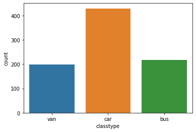

```python
sns.countplot('classtype', data=dataset)
```

# Observation

### In this vehicle dataset van, car and bus has been perform, but most performs the car

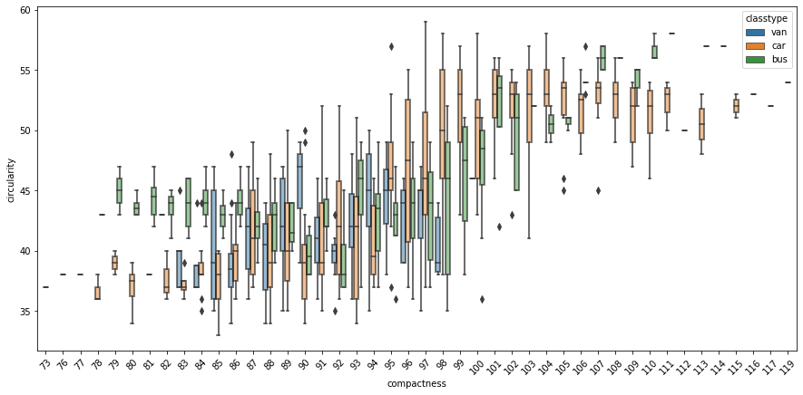

```python
plt.figure(figsize = (15, 7))
ax = sns.boxplot('compactness','circularity','classtype', data=dataset)
plt.setp(ax.artists, alpha=.5, linewidth=2, edgecolor="k")
plt.xticks(rotation=45)
```

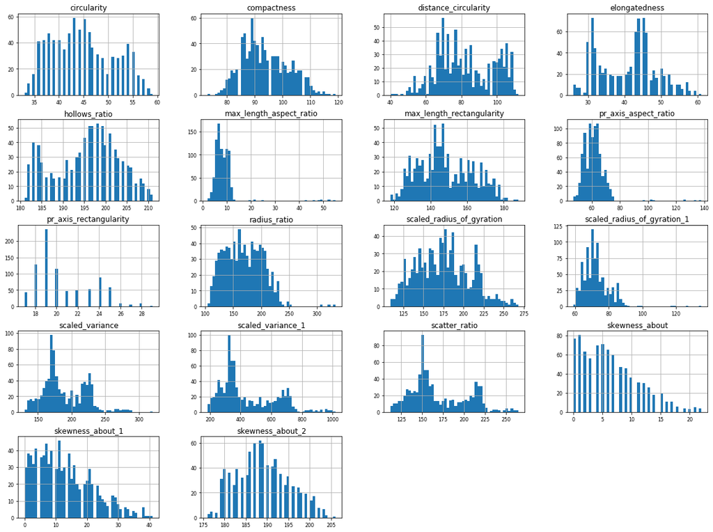

```python
dataset.hist(figsize=(20, 15), bins=50, xlabelsize=8, ylabelsize=8);
```

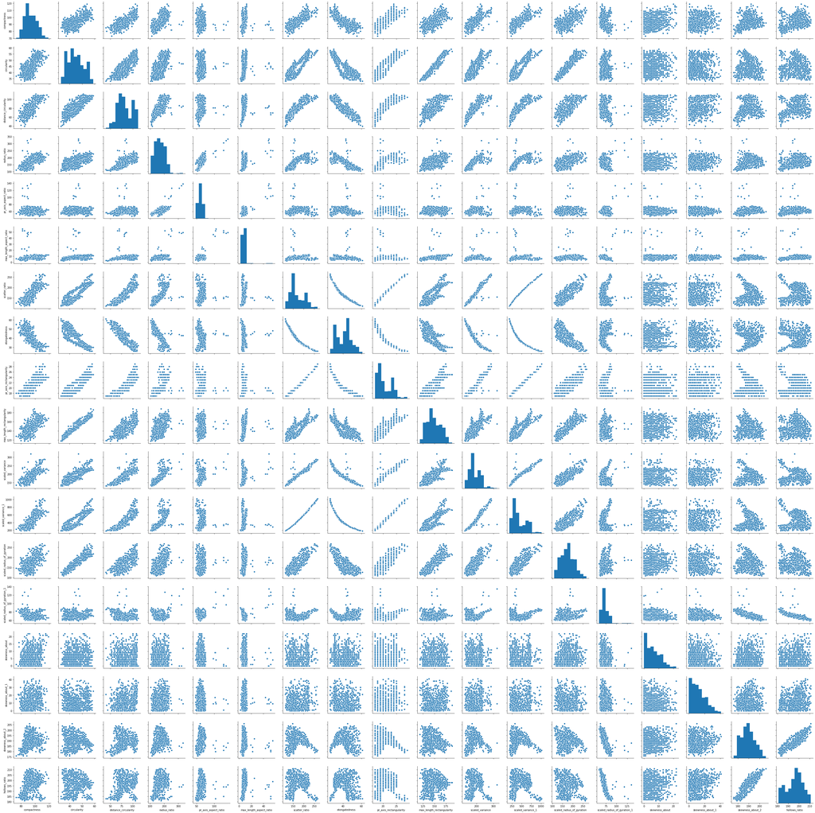

```python
sns.pairplot(dataset)
```

# Observation

### In this pairplot shows linear relationship of the dataset to apply the model.

```python
dataset.corr()
```

|  | compactness | circularity | distance_circularity | radius_ratio | pr_axis_aspect_ratio | max_length_aspect_ratio | scatter_ratio | elongatedness | pr_axis_rectangularity | max_length_rectangularity | scaled_variance | scaled_variance_1 | scaled_radius_of_gyration | scaled_radius_of_gyration_1 | skewness_about | skewness_about_1 | skewness_about_2 | hollows_ratio |
| --- | --- | --- | --- | --- | --- | --- | --- | --- | --- | --- | --- | --- | --- | --- | --- | --- | --- | --- |
| compactness | 1.000000 | 0.689786 | 0.791707 | 0.691081 | 0.091779 | 0.148249 | 0.812770 | -0.788736 | 0.814248 | 0.676143 | 0.764361 | 0.818674 | 0.585845 | -0.250603 | 0.236685 | 0.157670 | 0.298528 | 0.365552 |
| circularity | 0.689786 | 1.000000 | 0.797180 | 0.625051 | 0.154283 | 0.251407 | 0.858265 | -0.827246 | 0.856603 | 0.965729 | 0.806791 | 0.850863 | 0.935950 | 0.053080 | 0.144968 | -0.011869 | -0.106339 | 0.045652 |
| distance_circularity | 0.791707 | 0.797180 | 1.000000 | 0.771748 | 0.158684 | 0.264621 | 0.907949 | -0.913020 | 0.896273 | 0.775149 | 0.865710 | 0.890541 | 0.706950 | -0.227001 | 0.114665 | 0.266049 | 0.146027 | 0.333648 |
| radius_ratio | 0.691081 | 0.625051 | 0.771748 | 1.000000 | 0.665363 | 0.450486 | 0.738480 | -0.792946 | 0.712744 | 0.571083 | 0.798294 | 0.725598 | 0.541325 | -0.181520 | 0.049112 | 0.174469 | 0.382912 | 0.472339 |
| pr_axis_aspect_ratio | 0.091779 | 0.154283 | 0.158684 | 0.665363 | 1.000000 | 0.648861 | 0.103832 | -0.183492 | 0.079566 | 0.127322 | 0.273738 | 0.089750 | 0.122454 | 0.152860 | -0.058539 | -0.032180 | 0.240201 | 0.267760 |
| max_length_aspect_ratio | 0.148249 | 0.251407 | 0.264621 | 0.450486 | 0.648861 | 1.000000 | 0.165998 | -0.180053 | 0.161603 | 0.305943 | 0.319033 | 0.143745 | 0.189752 | 0.295638 | 0.015446 | 0.043491 | -0.026184 | 0.143919 |
| scatter_ratio | 0.812770 | 0.858265 | 0.907949 | 0.738480 | 0.103832 | 0.165998 | 1.000000 | -0.973504 | 0.992078 | 0.810017 | 0.951672 | 0.996328 | 0.800577 | -0.028006 | 0.074376 | 0.213512 | 0.005171 | 0.118504 |
| elongatedness | -0.788736 | -0.827246 | -0.913020 | -0.792946 | -0.183492 | -0.180053 | -0.973504 | 1.000000 | -0.950405 | -0.776150 | -0.938313 | -0.956488 | -0.766671 | 0.103535 | -0.052243 | -0.186027 | -0.114846 | -0.216769 |
| pr_axis_rectangularity | 0.814248 | 0.856603 | 0.896273 | 0.712744 | 0.079566 | 0.161603 | 0.992078 | -0.950405 | 1.000000 | 0.813135 | 0.938182 | 0.992316 | 0.798522 | -0.015711 | 0.083219 | 0.215200 | -0.019066 | 0.099481 |
| max_length_rectangularity | 0.676143 | 0.965729 | 0.775149 | 0.571083 | 0.127322 | 0.305943 | 0.810017 | -0.776150 | 0.813135 | 1.000000 | 0.746657 | 0.797485 | 0.866554 | 0.041283 | 0.136077 | 0.001660 | -0.104437 | 0.076770 |
| scaled_variance | 0.764361 | 0.806791 | 0.865710 | 0.798294 | 0.273738 | 0.319033 | 0.951672 | -0.938313 | 0.938182 | 0.746657 | 1.000000 | 0.949766 | 0.781016 | 0.112452 | 0.036165 | 0.196202 | 0.014434 | 0.086708 |
| scaled_variance_1 | 0.818674 | 0.850863 | 0.890541 | 0.725598 | 0.089750 | 0.143745 | 0.996328 | -0.956488 | 0.992316 | 0.797485 | 0.949766 | 1.000000 | 0.797318 | -0.016642 | 0.077288 | 0.202398 | 0.006648 | 0.103839 |
| scaled_radius_of_gyration | 0.585845 | 0.935950 | 0.706950 | 0.541325 | 0.122454 | 0.189752 | 0.800577 | -0.766671 | 0.798522 | 0.866554 | 0.781016 | 0.797318 | 1.000000 | 0.192245 | 0.166785 | -0.056067 | -0.225882 | -0.118597 |
| scaled_radius_of_gyration_1 | -0.250603 | 0.053080 | -0.227001 | -0.181520 | 0.152860 | 0.295638 | -0.028006 | 0.103535 | -0.015711 | 0.041283 | 0.112452 | -0.016642 | 0.192245 | 1.000000 | -0.088736 | -0.126686 | -0.752437 | -0.804793 |
| skewness_about | 0.236685 | 0.144968 | 0.114665 | 0.049112 | -0.058539 | 0.015446 | 0.074376 | -0.052243 | 0.083219 | 0.136077 | 0.036165 | 0.077288 | 0.166785 | -0.088736 | 1.000000 | -0.035154 | 0.115728 | 0.097293 |
| skewness_about_1 | 0.157670 | -0.011869 | 0.266049 | 0.174469 | -0.032180 | 0.043491 | 0.213512 | -0.186027 | 0.215200 | 0.001660 | 0.196202 | 0.202398 | -0.056067 | -0.126686 | -0.035154 | 1.000000 | 0.077460 | 0.205115 |
| skewness_about_2 | 0.298528 | -0.106339 | 0.146027 | 0.382912 | 0.240201 | -0.026184 | 0.005171 | -0.114846 | -0.019066 | -0.104437 | 0.014434 | 0.006648 | -0.225882 | -0.752437 | 0.115728 | 0.077460 | 1.000000 | 0.893869 |
| hollows_ratio | 0.365552 | 0.045652 | 0.333648 | 0.472339 | 0.267760 | 0.143919 | 0.118504 | -0.216769 | 0.099481 | 0.076770 | 0.086708 | 0.103839 | -0.118597 | -0.804793 | 0.097293 | 0.205115 | 0.893869 | 1.000000 |

```python
dataset.isnull().sum()
```

```
compactness                    0
circularity                    5
distance_circularity           4
radius_ratio                   6
pr_axis_aspect_ratio           2
max_length_aspect_ratio        0
scatter_ratio                  1
elongatedness                  1
pr_axis_rectangularity         3
max_length_rectangularity      0
scaled_variance                3
scaled_variance_1              2
scaled_radius_of_gyration      2
scaled_radius_of_gyration_1    4
skewness_about                 6
skewness_about_1               1
skewness_about_2               1
hollows_ratio                  0
classtype                      0
dtype: int64
```

## Data Pre-Processing

### Check whether there is any NA's

```python
dataset.fillna(dataset.mean(),inplace=True)
```

# Observation

### Missing values with mean (Numerical Variables)

```python
dataset.isnull().sum()
```

```
compactness                    0
circularity                    0
distance_circularity           0
radius_ratio                   0
pr_axis_aspect_ratio           0
max_length_aspect_ratio        0
scatter_ratio                  0
elongatedness                  0
pr_axis_rectangularity         0
max_length_rectangularity      0
scaled_variance                0
scaled_variance_1              0
scaled_radius_of_gyration      0
scaled_radius_of_gyration_1    0
skewness_about                 0
skewness_about_1               0
skewness_about_2               0
hollows_ratio                  0
classtype                      0
dtype: int64
```

# Observation

### Again check there is any NA's

```python
dataset.circularity.fillna(dataset.circularity.mode()[0],inplace=True)
dataset.distance_circularity.fillna(dataset.distance_circularity.mode()[0],inplace=True)
dataset.radius_ratio.fillna(dataset.radius_ratio.mode()[0],inplace=True)
dataset.pr_axis_aspect_ratio.fillna(dataset.pr_axis_aspect_ratio.mode()[0],inplace=True)
dataset.scatter_ratio.fillna(dataset.scatter_ratio.mode()[0],inplace=True)
dataset.elongatedness.fillna(dataset.elongatedness.mode()[0],inplace=True)
dataset.pr_axis_rectangularity.fillna(dataset.pr_axis_rectangularity.mode()[0],inplace=True)
dataset.scaled_variance.fillna(dataset.scaled_variance.mode()[0],inplace=True)
dataset.scaled_variance_1.fillna(dataset.scaled_variance_1.mode()[0],inplace=True)
dataset.scaled_radius_of_gyration.fillna(dataset.scaled_radius_of_gyration.mode()[0],inplace=True)
dataset.scaled_radius_of_gyration_1.fillna(dataset.scaled_radius_of_gyration_1.mode()[0],inplace=True)
dataset.skewness_about.fillna(dataset.skewness_about.mode()[0],inplace=True)
dataset.skewness_about_1.fillna(dataset.skewness_about_1.mode()[0],inplace=True)
dataset.skewness_about_2.fillna(dataset.skewness_about_2.mode()[0],inplace=True)
```

# Observation

### To find missing values with mode (categorical variables)

### There is totally 19 columns are there, In this 14 columns has some null values, we have to replace the NA's

```python
dataset.isnull().sum()
```

```
compactness                    0
circularity                    0
distance_circularity           0
radius_ratio                   0
pr_axis_aspect_ratio           0
max_length_aspect_ratio        0
scatter_ratio                  0
elongatedness                  0
pr_axis_rectangularity         0
max_length_rectangularity      0
scaled_variance                0
scaled_variance_1              0
scaled_radius_of_gyration      0
scaled_radius_of_gyration_1    0
skewness_about                 0
skewness_about_1               0
skewness_about_2               0
hollows_ratio                  0
classtype                      0
dtype: int64
```

```python
dataset.shape
```

```
(846, 19)
```

```python
print("Total number of classes: {}".format(dataset.shape[0]))
print("Number of car: {}".format(dataset[dataset.classtype == 'car'].shape[0]))
print("Number of bus: {}".format(dataset[dataset.classtype == 'bus'].shape[0]))
print("Number of van: {}".format(dataset[dataset.classtype == 'van'].shape[0]))
```

```
Total number of classes: 846
Number of car: 429
Number of bus: 218
Number of van: 199
```

```python
X=dataset.iloc[:, :-1]
X.head()
```

|  | compactness | circularity | distance_circularity | radius_ratio | pr_axis_aspect_ratio | max_length_aspect_ratio | scatter_ratio | elongatedness | pr_axis_rectangularity | max_length_rectangularity | scaled_variance | scaled_variance_1 | scaled_radius_of_gyration | scaled_radius_of_gyration_1 | skewness_about | skewness_about_1 | skewness_about_2 | hollows_ratio |
| --- | --- | --- | --- | --- | --- | --- | --- | --- | --- | --- | --- | --- | --- | --- | --- | --- | --- | --- |
| 0 | 95 | 48.0 | 83.0 | 178.0 | 72.0 | 10 | 162.0 | 42.0 | 20.0 | 159 | 176.0 | 379.0 | 184.0 | 70.0 | 6.0 | 16.0 | 187.0 | 197 |
| 1 | 91 | 41.0 | 84.0 | 141.0 | 57.0 | 9 | 149.0 | 45.0 | 19.0 | 143 | 170.0 | 330.0 | 158.0 | 72.0 | 9.0 | 14.0 | 189.0 | 199 |
| 2 | 104 | 50.0 | 106.0 | 209.0 | 66.0 | 10 | 207.0 | 32.0 | 23.0 | 158 | 223.0 | 635.0 | 220.0 | 73.0 | 14.0 | 9.0 | 188.0 | 196 |
| 3 | 93 | 41.0 | 82.0 | 159.0 | 63.0 | 9 | 144.0 | 46.0 | 19.0 | 143 | 160.0 | 309.0 | 127.0 | 63.0 | 6.0 | 10.0 | 199.0 | 207 |
| 4 | 85 | 44.0 | 70.0 | 205.0 | 103.0 | 52 | 149.0 | 45.0 | 19.0 | 144 | 241.0 | 325.0 | 188.0 | 127.0 | 9.0 | 11.0 | 180.0 | 183 |

# Observation

### Separating features and labels

```python
from sklearn.preprocessing import LabelEncoder
y=dataset.iloc[:,-1]
```